# Assignment-2

14119666

2024-12-17

# Question 1

This experiment is a between-participants experiment collected data from 96 participants. The aim of it is to explore whether there is a difference for people to pronounce a word in normal condition vs. in visually degraded condition. So the between-participants factor is visual quality in two levels( normal or degraded ),and the dependent variable is response time. We want to explore and interpret the effect of visual quality on response time by building an ANOVA model.

## 1. Data wrangling

First，upload package and dataset1.

```r
#upload package "tidyverse", a package for easier and tidier data analysis, contains a number of useful commands, including the one we'll use next to upload the database—"read.csv()".
library( tidyverse )


#"<-"indicates assigning the value of the latter to the former; "read.csv()" is specially used to upload dataset according to the name or road in "()"
data1 <- read.csv("assignment_2_dataset_1.csv")
```

Then, check data1 and get a basic understanding of the data (I didn’t use “head()” because somehow the output of my R after executing the head command doesn’t show the type of variables).

```r
glimpse( data1 ) #"glimpse" aims to check variables and which categories they belong to.
```

```
## Rows: 96
## Columns: 3
## $ participant   <int> 1, 2, 3, 4, 5, 6, 7, 8, 9, 10, 11, 12, 13, 14, 15, 16, 1…
## $ condition     <chr> "condition_a", "condition_a", "condition_a", "condition_…
## $ response_time <dbl> 981.7994, 995.8570, 1007.4346, 977.8052, 1006.1114, 1002…
```

Obviously, there are three variables in data1: independent variable “condition”(condition_a&condition_b), the dependent variable “response_time”, and the id variable “participant” representing different participants. Since character variables are not available for data analysis, first we need to transform condition into factor variable.As the name “condition_a” is not very readable, I decided to transform the vague “condition” into an explicit “normal” with “degraded”.

```r
#“%>%” is used to indicate the database before it is used, to simplify the code
data1_tidied <- data1 %>%

  #"mutate()" is used to creating a new column or amending existing column
  mutate( condition = factor( condition ), #transform "condition" into factor variable

          #recode() is used to rename the value of factor variable.
          condition = recode( condition,
                              condition_a = "normal",
                              condition_b = "degraded")) %>%

  ###Obviously, "rename()" is used to rename a variable.
  rename( RT = response_time )

#Check whether data has been modified successfully
glimpse( data1_tidied )
```

```
## Rows: 96
## Columns: 3
## $ participant <int> 1, 2, 3, 4, 5, 6, 7, 8, 9, 10, 11, 12, 13, 14, 15, 16, 17,…
## $ condition   <fct> normal, normal, normal, normal, normal, normal, normal, no…
## $ RT          <dbl> 981.7994, 995.8570, 1007.4346, 977.8052, 1006.1114, 1002.6…
```

Everything is as expected.

Before analyse the data, the final thing we need to do is to check whether there are any missing values in it.

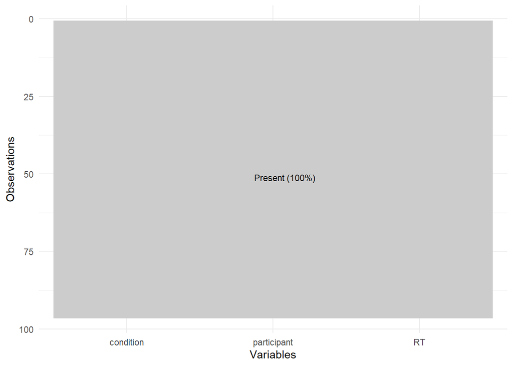

```r
#The font of the full text is specified according to APA format: all fonts are "sans", size 10 for body text, bold 11 for titles, and the above includes words in plots..
theme_set(theme_minimal( base_size = 10, base_family = "sans")+
            theme( plot.title = element_text( size = 11,
                                              face = "bold",
                                              family = "sans"),
                   axis.title = element_text( size = 11,
                                              family = "sans"),
                   axis.text = element_text( size = 10,
                                             family = "sans")))

#upload "visdat", a package that is used to initially visualize a dataset to understand the structure and characteristics of it
library( visdat )

#"vis_miss()" is used to visualise the missing values in a dataset
vis_miss( data1_tidied ) +


  scale_x_discrete( position = "bottom" ) + #replace the default X-axis

  #minimize the backgroud of the plot to make it more tidy
  theme_minimal() +

  #"legend position = ()" is used to putting legend within plot to conform to APA format requirements, "( 0.5,0.5)" means put legend into the center of this plot.
  theme( legend.position = c( 0.5,0.5 )) +

  #add the names of the x axis and the y axis
  labs( x = "Variables", y = "Observations")
```

There is no missing data in data1, we can start our statistic analysis now.

## 2. Statistic summary

```r
data1_tidied %>%

  #Group data1_tidied according to the conditions in parentheses
  group_by( condition ) %>%

  #calculating RTs' mean and sd
  summarise( mean = mean( RT ), median = median(RT), sd = sd( RT ))
```

```
## # A tibble: 2 × 4
##   condition  mean median    sd
##   <fct>     <dbl>  <dbl> <dbl>
## 1 normal    1001.  1002.  18.9
## 2 degraded  1016.  1020.  19.3
```

It can be seen that the visually normal group is smaller than the visually degraded group in terms of mean, median and sd.

In order to visualize this difference more clear, I decide to draw a violin plot.

## 3. Data visulization

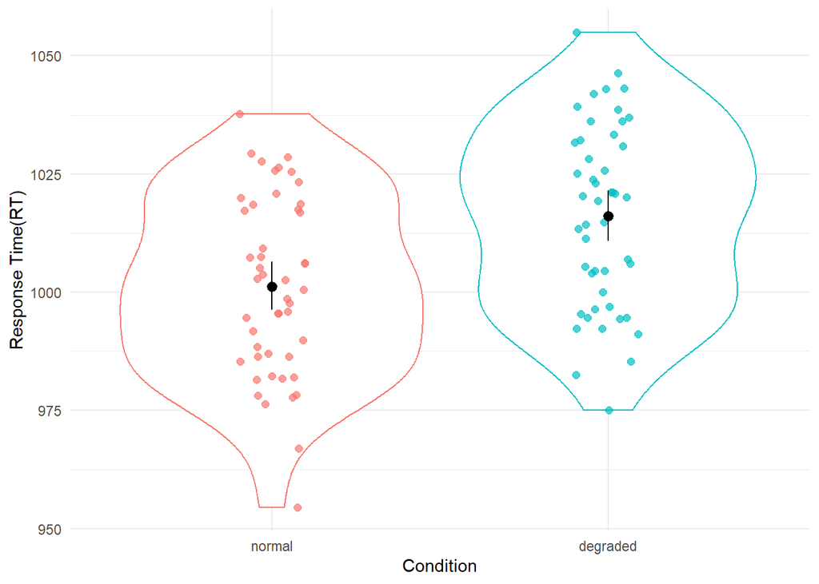

```r
data1_tidied %>%

  #"ggplot()" is used to draw plots in R, "aes()" tells R which variables are the x axis and the y axis, and color the plot according to "condition".
  ggplot( aes( x = condition, y = RT, colour = condition )) +

  geom_violin() + #draw violin plot

  #Plot the scatterplot and dither it appropriately, the value of "width" determines the magnitude of dithering, "size" determines the size of the points, and "alpha" determines the transparency of the points.
  geom_jitter( width = .1, size = 2, alpha = .7 ) +

  #to tidy the plot，remove legend
  guides( colour = 'none' ) +

  #Black confidence intervals are plotted using the mean as aggregation information. "fun.data = mean_cl_boot" used to specify the statistical values to be calculated (in this case the mean) and the upper and lower limits of the confidence interval, "colour =" specify the colour of this confidence interval.
  stat_summary( fun.data = "mean_cl_boot", colour = "black" ) +

  theme_minimal() +

  labs( x = "Condition", y = "Response Time(RT)")
```

From the plot above, there seems to be a gap between normal group and degraded group. In order to verify whether this gap is significant or not, the next step I will do is performing a between-subject ANOVA.

## 4. Build anova model

```r
library(afex) #This is a package for factorial data analysis, we will mainly use the "aov_ez" in it to do ANOVA analyses.

#"aov_ez()" is used to build anova model
model1 <- aov_ez( id = 'participant', #id variables
                   dv = 'RT', #dependent variables
                   between = 'condition', #between-subject ANOVA
                   data = data1_tidied ) #which dataset data comes from.

#check the details of this model
summary( model1 )
```

```
## Anova Table (Type 3 tests)
##
## Response: RT
##           num Df den Df    MSE      F    ges    Pr(>F)
## condition      1     94 363.97 14.508 0.1337 0.0002489 ***
## ---
## Signif. codes:  0 '***' 0.001 '**' 0.01 '*' 0.05 '.' 0.1 ' ' 1
```

I didn’t use “emmeans()” after this, because the independent variable only has two dimensions and I don’t think there is a need to do so.

Then, check the validity of model1 to confirm that it can effectively interpret the data in dataset1 and predict future trends.

## 5. Build linear model

I would like to get specific number on the relationship between visual quality and response time, but what ANOVA can do is just tell me if there’s a relationship between the two.Therefore, I need to build a linear model that is equivalent to model1 to achieve that.

```r
#"lm()" is used to build the linear model, before and after "~" are the dependent and independent variables, and "data =" specifies where data comes from.
data1_lm <- lm( RT ~ condition, data = data1_tidied )

data1_lm #View model "data1_lm"
```

```
##
## Call:
## lm(formula = RT ~ condition, data = data1_tidied)
##
## Coefficients:
##       (Intercept)  conditiondegraded
##           1001.19              14.83
```

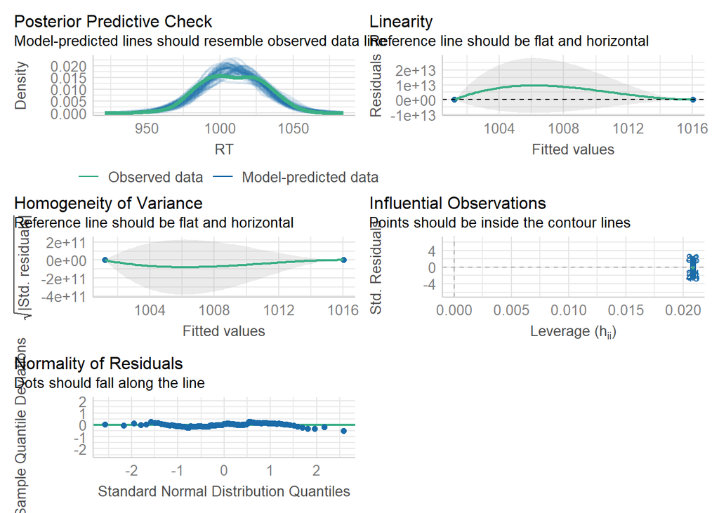

```r
#upload package "performance", which is used to quickly visualize models.
library( performance)

#output the plot you need, like "outliers", "QQ", "homegeneity", etc.
check_model( data1_lm )
```

## 6. Result

A between-subject ANOVA is conducted to determine the effect of visual quality on response time, and the following results can be found：

①A significant correlation can be found between visual quality and participants’ reaction time(F(1,94) = 14.508, ρ < 0.001, ηG2 = 0.134). That is, degraded visual words would significantly increase participants’ response time.

②Equation:RT (ms)= 1001.19 + 14.83( condition = degraded ).

In conclusion, humans respond significantly slower to visually degraded words compared to the normal words；The mean response time to the normal word is 1001.19 ms. while the response time to the visually degraded word is prolonged by 14.83 ms., which is 1016.02 ms..

# Question 2

Dataset2 is the same as dataset1, except a new variable “caffeine”, the number of cups of coffee participants drunk, is added. Our aim is to investigate the effect of visual quality on response time while considering the effect of caffeine consumption by conducting ANOVA. At the same time, we nned to build a linear model that is equivalent to our ANOVA model.

## 1. Data wrangling

First, upload data2 and check it

```r
##upload data_2
data2 <- read.csv("assignment_2_dataset_2.csv")

glimpse( data2 )
```

```
## Rows: 96
## Columns: 4
## $ participant   <int> 1, 2, 3, 4, 5, 6, 7, 8, 9, 10, 11, 12, 13, 14, 15, 16, 1…
## $ condition     <chr> "condition_a", "condition_a", "condition_a", "condition_…
## $ response_time <dbl> 981.7994, 995.8570, 1007.4346, 977.8052, 1006.1114, 1002…
## $ caffeine      <int> 1, 3, 4, 1, 3, 2, 4, 4, 2, 4, 2, 0, 1, 3, 2, 2, 1, 3, 3,…
```

As what we done with data1, we turn “condition” into a factor variable and increase its readability; then, rename “response_time” into “RT” while transform “caffeine” into factor variable.

```r
data2_tidied <- data2 %>%

  mutate( condition = factor( condition),
          caffeine = factor( caffeine ),
          condition = recode( condition, condition_a = "normal", condition_b = "degraded" )) %>%

  rename( RT = response_time )

glimpse( data2_tidied )
```

```
## Rows: 96
## Columns: 4
## $ participant <int> 1, 2, 3, 4, 5, 6, 7, 8, 9, 10, 11, 12, 13, 14, 15, 16, 17,…
## $ condition   <fct> normal, normal, normal, normal, normal, normal, normal, no…
## $ RT          <dbl> 981.7994, 995.8570, 1007.4346, 977.8052, 1006.1114, 1002.6…
## $ caffeine    <fct> 1, 3, 4, 1, 3, 2, 4, 4, 2, 4, 2, 0, 1, 3, 2, 2, 1, 3, 3, 2…
```

It can be seen that everything is done perfectly, then we need to check whether there are missing values in this dataset.

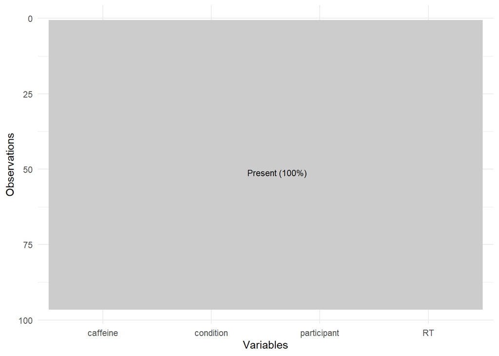

```r
vis_miss( data2_tidied ) +

  scale_x_discrete( position = "bottom" ) + #replace the default X-axis

  theme_minimal() +

  theme( legend.position = c( 0.5,0.5 )) +

  labs( x = "Variables",
        y = "Observations")
```

Nice, there is no missing value been observed,then let’s perform basic summary statistics, observe the response time under different visual qualities

## 2. summary statistics

```r
data2_tidied %>%

  #Group "data2_tidied" based on two grouping conditions: condition and caffeine.
  group_by( condition, caffeine ) %>%

  summarise( mean = mean( RT ), sd = sd( RT ))
```

```
## # A tibble: 13 × 4
## # Groups:   condition [2]
##    condition caffeine  mean    sd
##    <fct>     <fct>    <dbl> <dbl>
##  1 normal    0         966. 16.8
##  2 normal    1         984.  9.97
##  3 normal    2         997. 13.0
##  4 normal    3        1010. 15.3
##  5 normal    4        1019.  9.28
##  6 normal    5        1024.  7.63
##  7 degraded  1         995. 12.2
##  8 degraded  2         996. 13.1
##  9 degraded  3        1011. 15.8
## 10 degraded  4        1025. 13.8
## 11 degraded  5        1030. 15.0
## 12 degraded  6        1030.  9.81
## 13 degraded  7        1055. NA
```

From the results, it is clear that the mean RTs of the participants are not the same when the level of caffeine intake is different under the same visual conditions. For example, When participants see words that are normal words, but their caffeine intake increase from 0 to 2, the corresponding response times also increase from 966.34ms, to 983.74ms, until 996.77ms. Therefore，caffeine might be the covariate between visual quality and RT. So I’ll build ANCOVA model to determine it.

NA can be observed in sd，because the variable degraded has only one value for this dimension, so no sd can be calculated. In my opinion, this data point should be removed because there are too few data points for this dimension to reflect the true statistical distribution. But for the sake of rigor, I’ll construct two models, one that doesn’t exclude that point, and one does, and then compare which of the two models has a better fit.

## 3. Build ANCOVA model

### Build the initial ANCOVA

First, Creating the initial ANCOVA without removing any data point.

```r
data2_ancova1 <- aov_ez( id = 'participant',
                   dv = 'RT',
                   between = 'condition',
                   covariate = 'caffeine', #indicate covariates
                   data = data2_tidied)

#check the model we just built
anova( data2_ancova1 )
```

```
## Anova Table (Type 3 tests)
##
## Response: RT
##           num Df den Df    MSE       F    ges    Pr(>F)
## condition      1     87 176.57  1.2626 0.0143    0.2643
## caffeine       7     87 176.57 15.2518 0.5510 7.295e-13 ***
## ---
## Signif. codes:  0 '***' 0.001 '**' 0.01 '*' 0.05 '.' 0.1 ' ' 1
```

### Build initial linear model

Then I’m going to create linear models equivalent to ANCONA to facilitate comparison between models.

First，draw violin plot，observe the distribution of different variables at different levels.

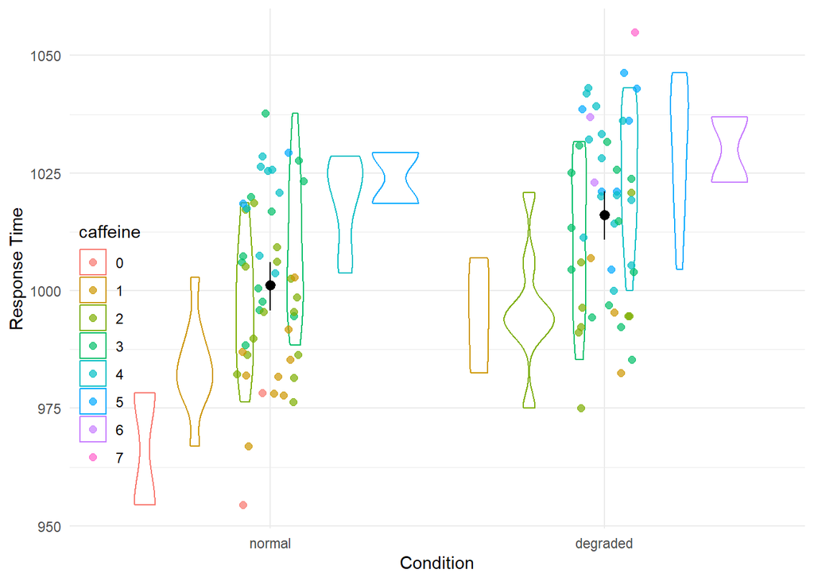

```r
data2_tidied %>%

  ggplot( aes( x = condition, y = RT, colour = caffeine )) +

  geom_violin() +

  geom_jitter( width = 0.1, alpha = 0.7, size = 2 ) +

  labs( x = "Condition",
        y = "Response Time") +

  stat_summary( fun.data = mean_cl_boot, colour = "black" ) +

  theme_minimal() +

  theme( legend.position = c( 0.055, 0.35 ),
         #adjust the location and format of legend
         plot.title = element_text( family = "sans",
                                    hjust = 0.5,
                                    face = "bold",
                                    size = 11))
```

It’s not hard to find that participants’ response time increased with the increase of caffeine levels regardless of the condition.

Then I want to check whether the current contrast coding mode is what I want it to be( normal = 0，degraded = 1 ).

```r
#"contrast()" is used to view the contrast coding of factor variables
contrasts( data1_tidied$condition)
```

```
##          degraded
## normal          0
## degraded        1
```

Last step，build initial linear model.

```r
data2_lm_ancova1 <- lm( RT ~ condition + caffeine,
                        data = data2_tidied )

data2_lm_ancova1
```

```
##
## Call:
## lm(formula = RT ~ condition + caffeine, data = data2_tidied)
##
## Coefficients:
##       (Intercept)  conditiondegraded          caffeine1          caffeine2
##            966.34               3.31              19.37              29.15
##         caffeine3          caffeine4          caffeine5          caffeine6
##             42.29              54.32              59.83              60.39
##         caffeine7
##             85.27
```

### Build the model that has removed data

At first, we need to remove the data we don’t need

```r
data2_removed <- data2_tidied %>%

  group_by( caffeine ) %>%

  filter( n() > 1 ) %>% #filter data for each level of caffeine，and only reserve those groups that contain more than 1 data point.

  ungroup %>% #stop group the dataset.

  mutate( caffeine = fct_drop( caffeine )) #Remove unused factor levels to avoid possible impacts
```

Next, build the second ANCOVA

```r
data2_ancova2 <- aov_ez( id = 'participant',
                          dv = 'RT',
                          between = 'condition',
                          covariate = 'caffeine',
                          data = data2_removed)

anova( data2_ancova2 )
```

```
## Anova Table (Type 3 tests)
##
## Response: RT
##           num Df den Df    MSE       F     ges    Pr(>F)
## condition      1     87 176.57  1.2626 0.01430    0.2643
## caffeine       6     87 176.57 16.3358 0.52977 1.646e-12 ***
## ---
## Signif. codes:  0 '***' 0.001 '**' 0.01 '*' 0.05 '.' 0.1 ' ' 1
```

### Build an equivalent linear model

Since only one point has been removed, the voilin plot is almost the same as the one above, so there is no need to draw it again. So we directly build the linear model.

```r
data2_lm_ancova2 <- lm( RT ~ condition + caffeine,
                        data = data2_removed )

data2_lm_ancova2
```

```
##
## Call:
## lm(formula = RT ~ condition + caffeine, data = data2_removed)
##
## Coefficients:
##       (Intercept)  conditiondegraded          caffeine1          caffeine2
##            966.34               3.31              19.37              29.15
##         caffeine3          caffeine4          caffeine5          caffeine6
##             42.29              54.32              59.83              60.39
```

## 4. Comparing

Both two models are built, let’s compare the two linear models to see who fits better.

```r
##AIC(model_a,model_b) is Used to compare which of two models has better predictive power (the one with the smaller value)
AIC( data2_lm_ancova2, data2_lm_ancova1 )
```

```
##                  df      AIC
## data2_lm_ancova2  9 770.7454
## data2_lm_ancova1 10 779.6638
```

The AIC value of data2_lm_ancova, which has filtered the point, is 770.75，smaller than another model(AIC = 779.66). Therefore, data2_ancova2 is better than data2_ancova1, we should filter that data point where the level of caffeine is 7.

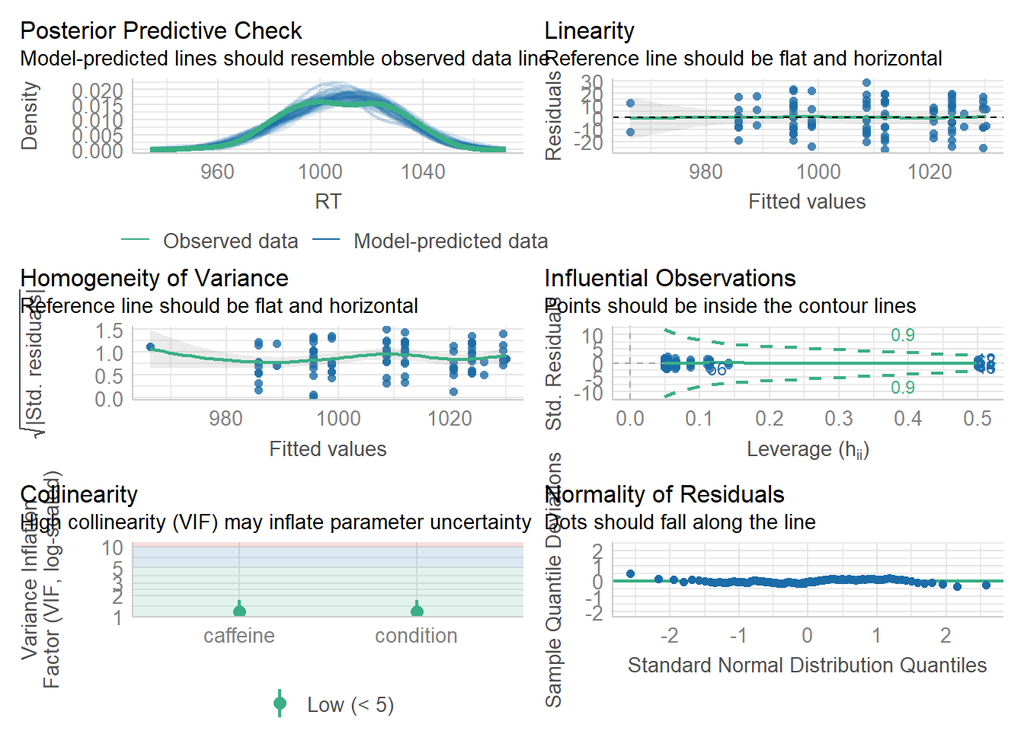

```r
check_model( data2_lm_ancova2 )
```

It can be seen that no matter normality of Residuals, homogeneity, outliers or Collinearity, this linear model fits well, and is a validity model.

## 5. Result

And based on the linear model we built, the equation below can be found: RT = 966.34 + 3.31( condition = degraded) + 19.37( caffeine = 1 ) + 29.15( caffeine = 2 ) + 42.29( caffeine = 3 ) + 54.32( caffeine = 4 ) + 59.83( caffeine = 5 ) + 60.39( caffeine = 6 ).

# Question 3

The data in dataset3 come from a 2( prime: positive vs. negative ) x 2( target: positive vs. negative ) repeated measures design experiment which recruited 148 participants. They were asked to respond to a prime( positive or negative, random but counter-balanced), and after that is a target image ( negative or positive, counter-balanced ). We want to explore whether people responded faster to positive images following a positive prime (relative to following a negative prime), and faster to negative images following a negative prime (relative to following a positive prime) by using repeated measures ANOVA.

## 1. Data wrangling

First, upload dataset3

```r
data3 <- read.csv("assignment_2_dataset_3.csv")

glimpse( data3 )
```

```
## Rows: 148
## Columns: 5
## $ participant                  <int> 1, 2, 3, 4, 5, 6, 7, 8, 9, 10, 11, 12, 13…
## $ positiveprime_positivetarget <dbl> 1501.903, 1535.374, 1562.939, 1492.393, 1…
## $ positiveprime_negativetarget <dbl> 1656.512, 1580.510, 1495.433, 1691.752, 1…
## $ negativeprime_positivetarget <dbl> 1534.891, 1622.606, 1544.842, 1600.562, 1…
## $ negativeprime_negativetarget <dbl> 1595.991, 1507.695, 1479.035, 1416.715, 1…
```

All data is correctly formatted and no need to be modified. Next, change data3 from 4 columns to 1 column for subsequent analyses.

```r
data3_longer <- data3 %>%

  #"pivot_longer" is used to change short date into longer data
  pivot_longer( c( positiveprime_positivetarget, positiveprime_negativetarget, negativeprime_positivetarget, negativeprime_negativetarget),
              names_to = "condition", #name of the new column
              values_to = "RT") #RT = response time

glimpse( data3_longer )
```

```
## Rows: 592
## Columns: 3
## $ participant <int> 1, 1, 1, 1, 2, 2, 2, 2, 3, 3, 3, 3, 4, 4, 4, 4, 5, 5, 5, 5…
## $ condition   <chr> "positiveprime_positivetarget", "positiveprime_negativetar…
## $ RT          <dbl> 1501.903, 1656.512, 1534.891, 1595.991, 1535.374, 1580.510…
```

As our analysis is based on “prime” and “target”, these two variables, we need to separate them.

```r
data3_separated <- data3_longer %>%

  #"separate()" is used to separate certain column into different columns according to specific sign.
  separate( col = condition, #specifies the column to be separated
            into = c( "prime", "target" ), #specifies the names of the separated columns respectively.
            sep = "_") #tells R based on which sign to separate the column.

glimpse( data3_separated )
```

```
## Rows: 592
## Columns: 4
## $ participant <int> 1, 1, 1, 1, 2, 2, 2, 2, 3, 3, 3, 3, 4, 4, 4, 4, 5, 5, 5, 5…
## $ prime       <chr> "positiveprime", "positiveprime", "negativeprime", "negati…
## $ target      <chr> "positivetarget", "negativetarget", "positivetarget", "neg…
## $ RT          <dbl> 1501.903, 1656.512, 1534.891, 1595.991, 1535.374, 1580.510…
```

Next, rename variables to make them more easy to read and more tidy, because the name,like “positiveprime”, is too long. And turn them into factor variables.

```r
data3_tidied <- data3_separated %>%

  mutate( prime = factor( prime ),

          target = factor( target ),

          prime = recode(prime, positiveprime = "positive", negativeprime = "negative"),

          target = recode( target, positivetarget = "positive", negativetarget = "negative"))

glimpse( data3_tidied )
```

```
## Rows: 592
## Columns: 4
## $ participant <int> 1, 1, 1, 1, 2, 2, 2, 2, 3, 3, 3, 3, 4, 4, 4, 4, 5, 5, 5, 5…
## $ prime       <fct> positive, positive, negative, negative, positive, positive…
## $ target      <fct> positive, negative, positive, negative, positive, negative…
## $ RT          <dbl> 1501.903, 1656.512, 1534.891, 1595.991, 1535.374, 1580.510…
```

We’ve successfully renamed the value of prime and target image,and turned them into factor variables. Then check for NA in data3_tidied to avoid the impact of NA on subsequent data analyses.

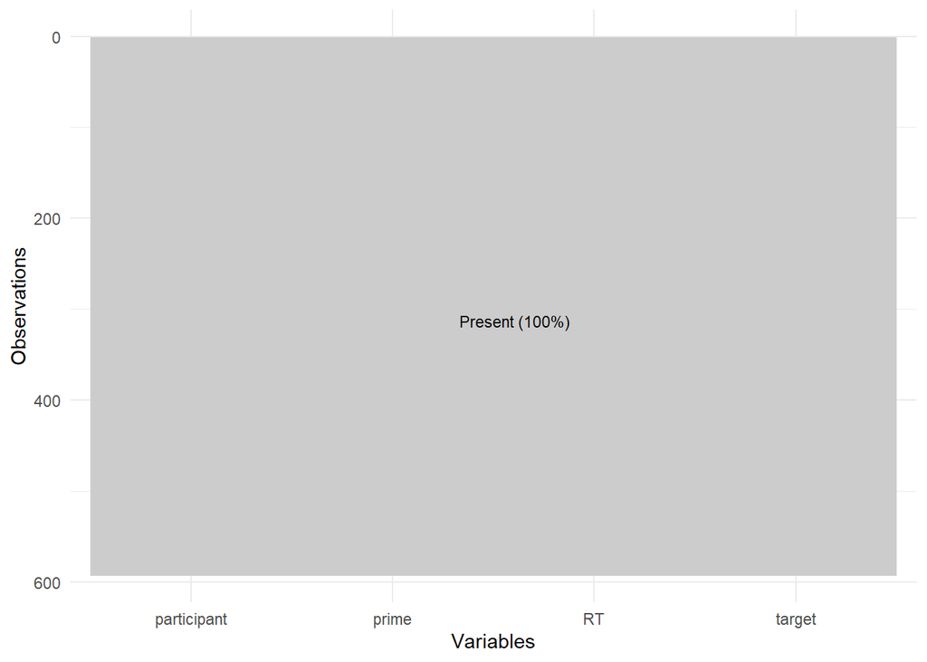

```r
vis_miss( data3_tidied ) +

  scale_x_discrete( position = "bottom" ) + #replace the default X-axis

  theme_minimal() +

  theme( legend.position = c( 0.5,0.5 )) +

  labs( x = "Variables",
        y = "Observations")
```

There is no missing value, so we can start to analyse data.

## 2. Statistic summary

```r
data3_tidied %>%

  group_by( prime, target ) %>%

  summarise( mean = mean( RT ), sd = sd( RT ))
```

```
## # A tibble: 4 × 4
## # Groups:   prime [2]
##   prime    target    mean    sd
##   <fct>    <fct>    <dbl> <dbl>
## 1 negative negative 1547.  52.4
## 2 negative positive 1563.  50.5
## 3 positive negative 1567.  54.0
## 4 positive positive 1547.  44.9
```

Obviously, the two groups with the same prime and targetimage had participants with smaller mean RT than the two groups with different prime and target image( 1547 < 1563, 1547 < 1567)；However, in terms of the sd of RT, it doesn’t seem to show a significant difference, except for the minimum sd = 44.9 ms when both prime and target image are positive.

## 3. Data visulization

In order to visualise the distribution of participants’ RTs and the differences between different conditions, I decided to draw a violin plot.

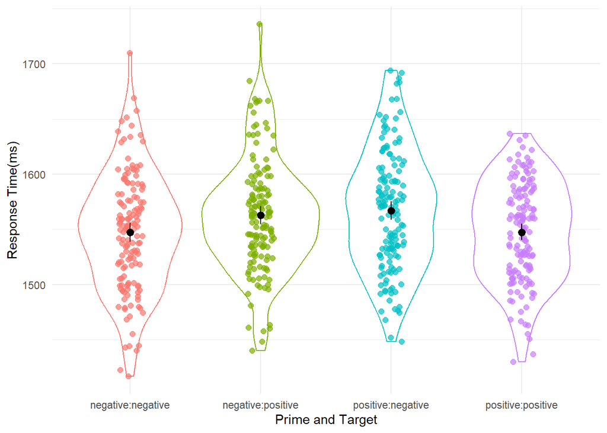

```r
data3_tidied %>%

  ggplot( aes( x = prime:target, y = RT, colour = prime:target)) +

  geom_violin() +

  geom_jitter( width = 0.1, size = 2, alpha = 0.7  ) +

  guides( colour = 'none') +

  stat_summary( fun.data = "mean_cl_boot", colour = "black") +

  theme_minimal() +

  labs( x = "Prime and Target",
        y = "Response Time(ms)")
```

I noticed there are two points that are far away from main area, which might be unusual points that need to be filtered. Therefore，I decided to build the linear model，and use codes in it to checks for anomalous data points.

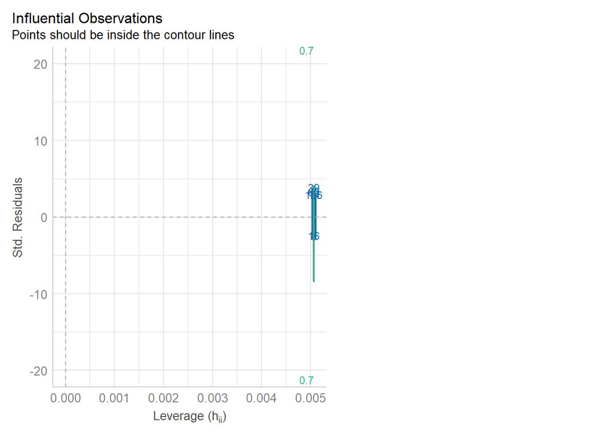

```r
data3_lm <- lm( RT ~ prime + target,
                data = data3_tidied )

check_model( data3_lm, check = "outliers")
```

From the results in the plot, there are no outliers, so there is no need to filter any points .

## 4. Build model

Then it comes to the next step，conduct ANOVA model.

```r
##build repeated measures anova model
data3_anova <- aov_ez( id = "participant",
                       dv = "RT",
                       #within-subject ANOVA
                       within = c("prime", "target"),
                       fun_aggregate = mean,
                       data = data3_tidied )

anova( data3_anova)
```

```
## Anova Table (Type 3 tests)
##
## Response: RT
##              num Df den Df    MSE       F       ges    Pr(>F)
## prime             1    147 2337.5  0.3157 0.0004908    0.5751
## target            1    147 2730.5  0.2375 0.0004315    0.6267
## prime:target      1    147 2626.3 17.2541 0.0292770 5.523e-05 ***
## ---
## Signif. codes:  0 '***' 0.001 '**' 0.01 '*' 0.05 '.' 0.1 ' ' 1
```

From the results, it is clear that the effects of prime and target image on response time are not significant individually, but their interaction has a strong effect on response time( F (1,147) = 17.25, ρ < 0.001, ηG2 = 0.0293 ).

Following this, we want to explore whether participants’ response times are shorter when the prime and target image both are positive or negative.

```r
#"emmeans" is used to compare whether there is a difference in means between dimensions of each variable
library(emmeans)

#Specify the variables "prime" and "target" in data3_anova, and compare each of their dimensions one by one.
#“adjust = 'none'"，which is because we want to compare the variables explicitly, we don't need to compare each variable and each dimension one by one, so we choose manual correction to reduce the probability of type 1 error.
emmeans( data3_anova, pairwise ~ prime*target, adjust = "none")
```

```
## $emmeans
##  prime    target   emmean   SE  df lower.CL upper.CL
##  negative negative   1547 4.30 147     1539     1556
##  positive negative   1567 4.44 147     1558     1576
##  negative positive   1563 4.15 147     1554     1571
##  positive positive   1547 3.69 147     1540     1555
##
## Confidence level used: 0.95
##
## $contrasts
##  contrast                              estimate   SE  df t.ratio p.value
##  negative negative - positive negative  -19.731 6.29 147  -3.138  0.0021
##  negative negative - negative positive  -15.405 5.98 147  -2.577  0.0110
##  negative negative - positive positive   -0.139 5.62 147  -0.025  0.9802
##  positive negative - negative positive    4.326 6.08 147   0.712  0.4776
##  positive negative - positive positive   19.591 6.05 147   3.236  0.0015
##  negative positive - positive positive   15.265 5.25 147   2.908  0.0042
```

## 5. Result

Results are below：

A 2( prime: positive vs. negative ) X 2( target: positive vs. negative ) repeated measures ANOVA is conducted to explore the effect of different emotional colours of prime and target image on response time, and whether participants’ RTs are faster when these two emotional colours are congruent than when they are incongruent.

The result of ANOVA tells us that there is no effect of prime(F(1,147) = 0.32, ρ = 0.575, ηG2 = 0.0005), nor target(F(1,147) = 0.24, ρ = 0.627, ηG2 = 0.0004), but an interaction between prime and target is founded(F(1,147) = 17.25, ρ = 5.523e-05, ηG2 = 0.0293).